# Assigmwent

2022-10-26

#Step 1: The IMDB dataset IMDB movie reviews is a labeled data set available within the text2vec package. This data set consists of 5000 IMDB movie reviews, specifically selected for sentiment analysis. The sentiment of the reviews is binary, meaning an IMDB rating < 5 results in a sentiment score of 0, and a rating >=7 has a sentiment score of 1. No individual movie has more than 30 reviews. Load the IMDB data set and split it into training (80%) and test (20%) sets.

```r
library(tidyverse)
```

```r
library(text2vec) # our dataset comes from this package
library(tidytext) # text transformation
library(wordcloud)
library(SnowballC)
# load an example dataset from text2vec
data("movie_review")
movie_review <- as_tibble(movie_review)
head(movie_review)
```

```
## # A tibble: 6 × 3
##   id     sentiment review
##   <chr>      <int> <chr>
## 1 5814_8         1 "With all this stuff going down at the moment with MJ i've s…
## 2 2381_9         1 "\\\"The Classic War of the Worlds\\\" by Timothy Hines is a…
## 3 7759_3         0 "The film starts with a manager (Nicholas Bell) giving welco…
## 4 3630_4         0 "It must be assumed that those who praised this film (\\\"th…
## 5 9495_8         1 "Superbly trashy and wondrously unpretentious 80's exploitat…
## 6 8196_8         1 "I dont know why people think this is such a bad movie. Its …
```

```r
#1 is good 0 is bad
```

Splitting data into train and test set (4000 reviews for train, 1000 reviews for test)

```r
## 80% of the sample size
smp_size <- floor(0.80 * nrow(movie_review))

## set the seed to make your partition reproducible
set.seed(123)
train_ind <- sample(seq_len(nrow(movie_review)), size = smp_size)

train <- movie_review[train_ind, ]
test<- movie_review[-train_ind, ]


head(train)
```

```
## # A tibble: 6 × 3
##   id      sentiment review
##   <chr>       <int> <chr>
## 1 4273_1          0 "There is nothing unique in either the TV Series nor the Mo…
## 2 7112_4          0 "Well I have to admit this was one of my favorites as a kid…
## 3 1891_3          0 "Documentary about nomadic Persians making a treacherous tr…
## 4 6252_10         1 "This film has got to be ranked as one of the most disturbi…
## 5 9929_2          0 "Watching this was like getting a large mackerel slapped in…
## 6 8970_10         1 "I researched this film a little and discovered a web site …
```

#Step 2: Document-term matrices Term frequency (TF) is the measurement of how frequently a term occurs within a document. Term frequency inverse document frequency (TFiDF) is a statistical measure that evaluates how relevant a word is to a document in a collection of documents. TFiDF is a bag-of-words method for vector representation of text data. Create two document-term matrices (dtms) with TF and TFiDF representations.

Counting total terms in the train set

```r
words <- train %>%
  unnest_tokens(tokens, input = review ) %>%
  count(id, tokens, sort = TRUE)


total_words <- words %>%
  group_by(id) %>%
  summarize(total = sum(n))


words <- left_join(words, total_words)
head(words)
```

```
## # A tibble: 6 × 4
##   id       tokens     n total
##   <chr>    <chr>  <int> <int>
## 1 2662_10  the      139  1629
## 2 4204_4   br        92   603
## 3 10595_10 the       90   982
## 4 8524_4   the       88   953
## 5 5137_4   the       85  1010
## 6 9503_4   br        84   501
```

Editing and adding some terms to our stop world dictionary

```r
#Editing stop word dictionary
df_stopwords <- stop_words  %>%

  #Adding a word to df_stopwords
  add_row(word= "br",lexicon="yo")  %>%
  #Adding a word to df_stopwords
  add_row(word= "<br",lexicon="yo")  %>%
  #Adding a word to df_stopwords
  add_row(word= "/><br",lexicon="yo")  %>%
  #Adding a word to df_stopwords
  add_row(word= "!",lexicon="yo")  %>%
  #Adding a word to df_stopwords
  add_row(word= "/",lexicon="yo")   %>%
    #Adding a word to df_stopwords
  add_row(word= "///",lexicon="yo")   %>%
   #Adding a word to df_stopwords
  add_row(word= "?",lexicon="yo")  %>%
 #Adding a word to df_stopwords
  add_row(word= "movie",lexicon="yo")   %>%
   #Adding a word to df_stopwords
  add_row(word= "film",lexicon="yo")
```

Removing stop words with antijoin

```r
#Delete from words stop words
words = anti_join(words,df_stopwords, by =c("tokens"="word"), copy = TRUE)
head(words)
```

```
## # A tibble: 6 × 4
##   id      tokens     n total
##   <chr>   <chr>  <int> <int>
## 1 1048_4  victor    31  1297
## 2 3538_10 bond      25   897
## 3 8673_7  match     25  1015
## 4 9031_10 homer     23   913
## 5 1048_4  vargas    22  1297
## 6 11434_2 gray      21   724
```

Visualizaing top words without stop words

```r
conteos = words %>%
  group_by(tokens)  %>%
  summarise(conteo = n())  %>%
  arrange(desc(conteo))

top_50 = head(conteos,50)
head(top_50)
```

```
## # A tibble: 6 × 2
##   tokens conteo
##   <chr>   <int>
## 1 time     1418
## 2 story    1200
## 3 people   1034
## 4 bad       926
## 5 watch     859
## 6 movies    856
```

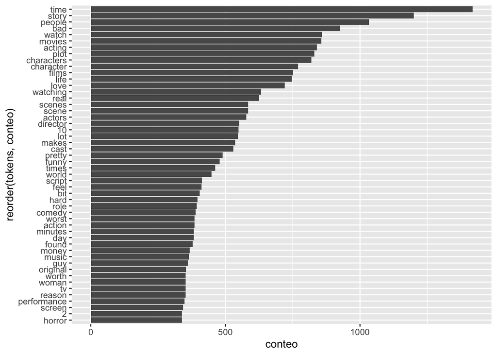

```r
ggplot(top_50, aes(x= reorder(tokens, conteo), y= conteo)) + geom_col() + coord_flip()
```

Steming words and joining

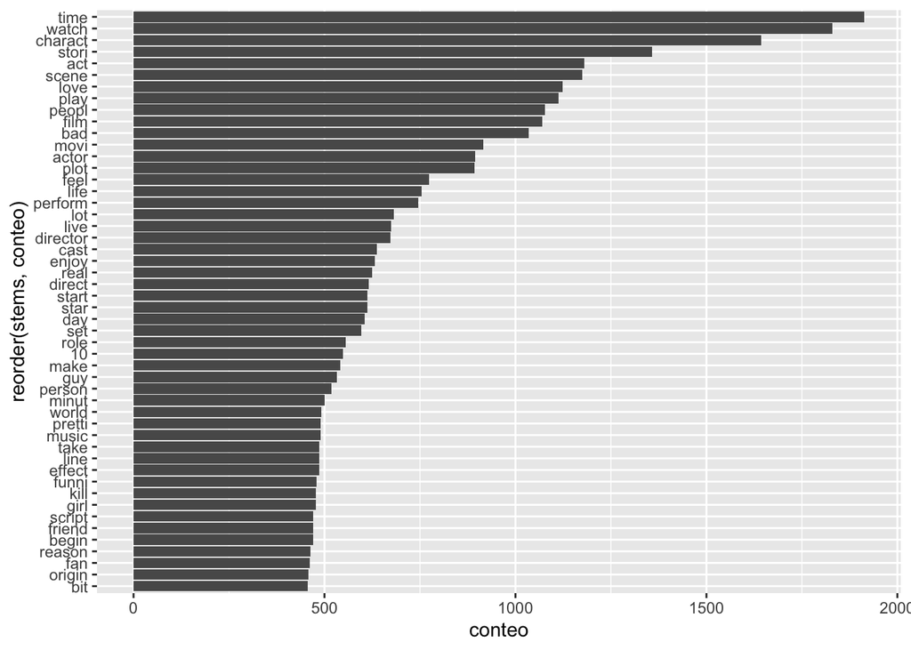

```r
stems = SnowballC::wordStem(words$tokens,language = "english")

stems = as.data.frame(stems)

conteos = stems %>%
  group_by(stems)  %>%
  summarise(conteo = n())  %>%
  arrange(desc(conteo))

top_50 = head(conteos,50)



ggplot(top_50, aes(x= reorder(stems, conteo), y= conteo)) + geom_col() + coord_flip()
```

```r
stem_words = cbind(words,stems)
head(stem_words)
```

```
##        id tokens  n total  stems
## 1  1048_4 victor 31  1297 victor
## 2 3538_10   bond 25   897   bond
## 3  8673_7  match 25  1015  match
## 4 9031_10  homer 23   913  homer
## 5  1048_4 vargas 22  1297  varga
## 6 11434_2   gray 21   724   gray
```

```r
remove(words)
remove(stems)
remove(top_50)
```

Creating tf-idf

```r
tf_idf <- stem_words %>%
  bind_tf_idf(stems, id, n)

head(tf_idf)
```

```
##        id tokens  n total  stems         tf      idf    tf_idf
## 1  1048_4 victor 31  1297 victor 0.06326531 4.860062 0.3074733
## 2 3538_10   bond 25   897   bond 0.06738544 4.323758 0.2913583
## 3  8673_7  match 25  1015  match 0.06613757 3.863233 0.2555048
## 4 9031_10  homer 23   913  homer 0.05822785 6.502290 0.3786144
## 5  1048_4 vargas 22  1297  varga 0.04489796 6.348139 0.2850185
## 6 11434_2   gray 21   724   gray 0.07553957 5.403678 0.4081915
```

Creating our own scores from tf and idf respectively

```r
stems_sen = tf_idf %>%
  inner_join(movie_review) %>%
  group_by(stems) %>%
  summarise(tf = mean(tf), tfidf = mean(tf_idf), sentiment = round(mean(sentiment),2) ) %>%
  arrange(desc(tf))
#Normalizing sentiments to negative and positive
stems_sen <- mutate(stems_sen,sentiment_real = (sentiment -1) + (sentiment ))
stems_sen <- mutate(stems_sen,tfsentiment = sentiment_real * tf,tfidfsentiment = sentiment_real * tfidf )
top_50 = head(stems_sen,70)

head(stems_sen)
```

```
## # A tibble: 6 × 7
##   stems        tf tfidf sentiment sentiment_real tfsentiment tfidfsentiment
##   <chr>     <dbl> <dbl>     <dbl>          <dbl>       <dbl>          <dbl>
## 1 colombo   0.267 2.21       0             -1        -0.267          -2.21
## 2 django    0.154 1.28       0             -1        -0.154          -1.28
## 3 filon     0.151 1.25       1              1         0.151           1.25
## 4 verri     0.143 1.18       1              1         0.143           1.18
## 5 smallvill 0.133 0.954      0.67           0.34      0.0451          0.324
## 6 auteuil   0.125 1.04       0             -1        -0.125          -1.04
```

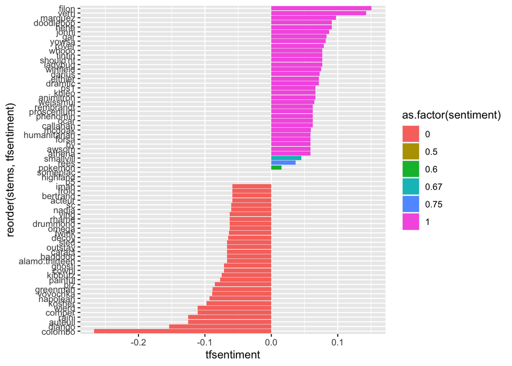

```r
ggplot(top_50 , aes(x= reorder(stems, tfsentiment), y= tfsentiment, fill = as.factor(sentiment))) + geom_col() + coord_flip()
```

Joining scores with the original stem df

```r
df = inner_join(stem_words,stems_sen)
df_id = inner_join(df,movie_review, by = c("id"))

head(df_id)
```

```
##        id tokens  n total  stems         tf      tfidf sentiment.x
## 1  1048_4 victor 31  1297 victor 0.01736811 0.08441011        0.55
## 2 3538_10   bond 25   897   bond 0.01123972 0.04859782        0.62
## 3  8673_7  match 25  1015  match 0.01543939 0.05964594        0.64
## 4 9031_10  homer 23   913  homer 0.02212620 0.14387096        0.83
## 5  1048_4 vargas 22  1297  varga 0.02017310 0.12806164        0.29
## 6 11434_2   gray 21   724   gray 0.01464089 0.07911465        0.50
##   sentiment_real  tfsentiment tfidfsentiment sentiment.y
## 1           0.10  0.001736811    0.008441011           0
## 2           0.24  0.002697533    0.011663477           1
## 3           0.28  0.004323028    0.016700863           1
## 4           0.66  0.014603290    0.094954831           1
## 5          -0.42 -0.008472701   -0.053785891           0
## 6           0.00  0.000000000    0.000000000           0
##                                                                                                                                                                                                                                                                                                          …
## 1 Raising Victor Vargas: A Review<br /><br />You know, Raising Victor Vargas is like sticking your hands into a big, steaming bowl of oatmeal. It's warm and gooey, but you're not sure if it feels right. Try as I might, no matter how warm and gooey Raising Victor Vargas became I was always aware t…
## 2                                                                                                                                                                                                                                                                                                        …
## 3                                                                                                                                                                                                                                                                                                        …
## 4                                                                                                                                                                                                                                                                                                        …
## 5 Raising Victor Vargas: A Review<br /><br />You know, Raising Victor Vargas is like sticking your hands into a big, steaming bowl of oatmeal. It's warm and gooey, but you're not sure if it feels right. Try as I might, no matter how warm and gooey Raising Victor Vargas became I was always aware t…
## 6                                                                                                                                                                                                                                                                                                        …
```

```r
df_scored = df_id %>%
  group_by(id)  %>%
  summarise(tfscore = mean(tfsentiment), tfidfscore = mean(tfidfsentiment))
head(df_scored)
```

```
## # A tibble: 6 × 3
##   id        tfscore tfidfscore
##   <chr>       <dbl>      <dbl>
## 1 10000_8  0.00115     0.00678
## 2 10001_4 -0.000638   -0.00726
## 3 10004_3 -0.00226    -0.0146
## 4 10004_8  0.00136     0.00677
## 5 10006_4 -0.00211    -0.0145
## 6 10008_7  0.000970    0.00419
```

```r
df_scored_sen = inner_join(df_scored,movie_review, by = c("id"))
head(df_scored_sen)
```

```
## # A tibble: 6 × 5
##   id        tfscore tfidfscore sentiment review
##   <chr>       <dbl>      <dbl>     <int> <chr>
## 1 10000_8  0.00115     0.00678         1 "Homelessness (or Houselessness as Geo…
## 2 10001_4 -0.000638   -0.00726         0 "This film lacked something I couldn't…
## 3 10004_3 -0.00226    -0.0146          0 "\\\"It appears that many critics find…
## 4 10004_8  0.00136     0.00677         1 "This isn't the comedic Robin Williams…
## 5 10006_4 -0.00211    -0.0145          0 "I don't know who to blame, the timid …
## 6 10008_7  0.000970    0.00419         1 "You know, Robin Williams, God bless h…
```

View of some top comments according to our score

```r
 # arrange the average sentiment score in descending order

or=  arrange(df_scored_sen,desc(tfidfscore))

# filter happiest reviews
movie_review %>%
  filter(id %in% head(or$id, 3)) %>%
  pull(review)
```

```
## [1] "This show is so full of action, and everything needed to make an awsome show.. but best of all... it actually has a plot (unlike some of those new reality shows...). It is about a transgenic girl who escapes from her military holding base.. I totally suggest bying the DVDs, i've already preo…
## [2] "A milestone in Eastern European film making and an outstanding example of Serbian mentality. A group of completely different people are doomed to die because of their discord. With \\\"Maratonci trce pocasni krug\\\" makes two mythological movies everyone here knows word by word."
## [3] "Along with the \\\"Maratonci trce pocasni krug\\\" from the same director, one of the masterpieces of ex-Yugoslavia comedies. If you want to understand Serbian mentality, you must see this movie. And if you want to see several of ex-Yugoslav great actors at the same time, this is a opportuni…
```

#TREATING TEST DATA BY SEPARATELY

```r
words <- test %>%
  unnest_tokens(tokens, input = review ) %>%
  count(id, tokens, sort = TRUE)


total_words <- words %>%
  group_by(id) %>%
  summarize(total = sum(n))


words <- left_join(words, total_words)
head(words)
```

```
## # A tibble: 6 × 4
##   id     tokens     n total
##   <chr>  <chr>  <int> <int>
## 1 1175_9 the      198  2493
## 2 1175_9 and       98  2493
## 3 1175_9 to        85  2493
## 4 3488_7 the       78   927
## 5 8169_4 the       77   767
## 6 5473_2 the       74   990
```

```r
#Delete from words stop words , con copy se modifica el primer df
words = anti_join(words,df_stopwords, by =c("tokens"="word"), copy = TRUE)


#Stemizing test set
stems = SnowballC::wordStem(words$tokens,language = "english")

stems = as.data.frame(stems)



#Adding stems to test set
stem_words = cbind(words,stems)

remove(words)
remove(stems)



#grading test stems with train set stems scores
df = inner_join(stem_words,stems_sen)
df_id = inner_join(df,movie_review, by = c("id"))


#Gruping by id and getting scores
df_scored = df_id %>%
  group_by(id)  %>%
  summarise(tfscore = mean(tfsentiment), tfidfscore = mean(tfidfsentiment))
head(df_scored)
```

```
## # A tibble: 6 × 3
##   id        tfscore tfidfscore
##   <chr>       <dbl>      <dbl>
## 1 10012_1 -0.00317   -0.0140
## 2 10018_8  0.000866   0.00342
## 3 10027_1 -0.00255   -0.0150
## 4 10060_9  0.000763   0.000950
## 5 10073_4 -0.000906  -0.00425
## 6 10077_2 -0.000884  -0.00310
```

```r
df_scored_sen_test = inner_join(df_scored,movie_review, by = c("id"))
df_scored_sen_test
```

```
## # A tibble: 1,000 × 5
##    id         tfscore tfidfscore sentiment review
##    <chr>        <dbl>      <dbl>     <int> <chr>
##  1 10012_1  -0.00317   -0.0140           0 "This movie must be in line for the …
##  2 10018_8   0.000866   0.00342          1 "This Night Listener is better than …
##  3 10027_1  -0.00255   -0.0150           0 "The action in this movie beats Sunn…
##  4 10060_9   0.000763   0.000950         1 "Wang Bianlian is an old street perf…
##  5 10073_4  -0.000906  -0.00425          0 "Hollywood's misguided obsession wit…
##  6 10077_2  -0.000884  -0.00310          0 "Well, at least my theater group did…
##  7 10083_1  -0.00120   -0.00278          0 "They changed the title of this atro…
##  8 10091_1  -0.00247   -0.0120           0 "I cannot believe that this movie wa…
##  9 10105_8   0.000556   0.00200          1 "Directed by Govind Nihalani, this i…
## 10 10110_10  0.00143    0.0111           1 "Any story comprises a premise, char…
## # … with 990 more rows
```

Creating x and y dfs for each case

```r
train_tf_x <- select(df_scored_sen, tfscore, sentiment)
#train_tf_y <- select(train_tf, sentiment.y)

test_tf_x <- select(df_scored_sen_test, tfscore)
test_tf_y <- select(df_scored_sen_test, sentiment)

train_tfidf_x <- select(df_scored_sen, tfidfscore, sentiment)
#train_tfidf_y <- select(train_tfidf, sentiment.y)

test_tfidf_x <- select(df_scored_sen_test, tfidfscore)
test_tfidf_y <- select(df_scored_sen_test, sentiment)

remove(tfidf_df_sen)
remove(tf_df_sen)
remove(tf_df)
remove(tfidf_df)
head(train_tf_x)
```

```
## # A tibble: 6 × 2
##     tfscore sentiment
##       <dbl>     <int>
## 1  0.00115          1
## 2 -0.000638         0
## 3 -0.00226          0
## 4  0.00136          1
## 5 -0.00211          0
## 6  0.000970         1
```

#Step 3: Supervised learning: classification The two different document-term matrices you created can serve as input to a classifier, predicting the sentiment. Select two supervised learning methods for classifying the sentiments. You can choose any supervised learning method. Some options are:

- Naïve Bayes (e.g., package “e1071”)
- Support Vector Machines (e.g., package “e1071”)
- Regularized logistic regression (e.g., package “glmnet”)

# Selected Models:

- Logistic Regression
- Random Forest

```r
# Loading package
library(e1071)
library(caTools)
library(caret)
library(glmnet)
set.seed(120)  # Setting Seed
```

Step 4: Train and compare models Train your models on both TF and TFiDF dtms training data and compare their AUC and loss values on the test set.

Train and confusion matrix

```r
#Tf Logistic regression
model <- glm(sentiment ~.,family=binomial(link='logit'),data=train_tf_x)
#TEST SET
probs = predict(model, newdata = test_tf_x, type = "response")
predicted.classes <- ifelse(probs > 0.5, 1, 0)
# Confusion Matrix
cm <- table(test_tf_y$sentiment, predicted.classes)
print("Logistic regresion Tf model result in test set")
```

```
## [1] "Logistic regresion Tf model result in test set"
```

```r
cm
```

```
##    predicted.classes
##       0   1
##   0 395  90
##   1  71 444
```

```r
Accuracy_1 = (cm[1,1] + cm[2,2]) / (cm[1,1] + cm[2,2] + cm[1,2] + cm[2,1])
Accuracy_1
```

```
## [1] 0.839
```

```r
#calculate AUC
library(pROC)
auc(test_tf_y$sentiment, predicted.classes)
```

```
## Area under the curve: 0.8383
```

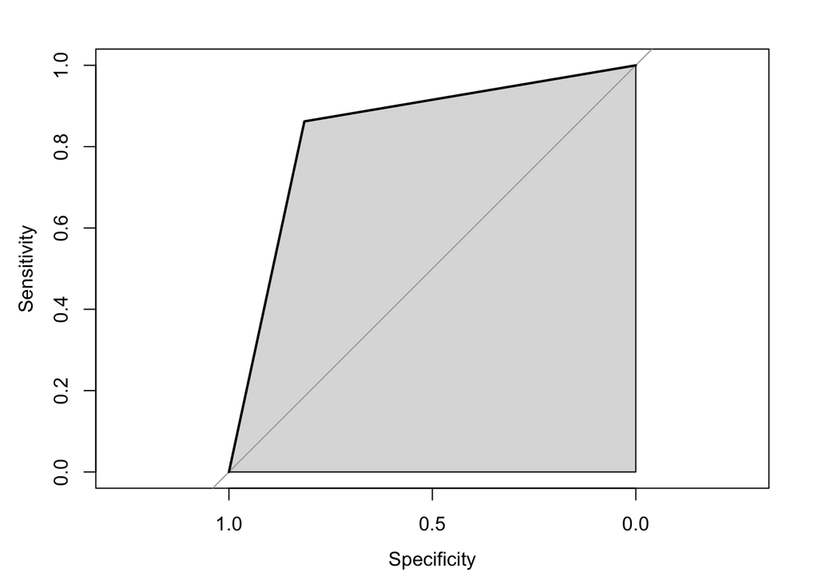

```r
#Plotting
plot(roc(test_tf_y$sentiment, predicted.classes), auc.polygon=TRUE)
```

```r
#Tfidf Logistic regression
model <- glm(sentiment ~.,family=binomial(link='logit'),data=train_tfidf_x)
#TEST SET
probs = predict(model, newdata = test_tfidf_x, type = "response")
predicted.classes <- ifelse(probs > 0.5, 1, 0)
# Confusion Matrix
cm <- table(test_tfidf_y$sentiment, predicted.classes)
print("Logistic regresion Tfidf model result in test set")
```

```
## [1] "Logistic regresion Tfidf model result in test set"
```

```r
cm
```

```
##    predicted.classes
##       0   1
##   0 372 113
##   1  79 436
```

```r
Accuracy_2 = (cm[1,1] + cm[2,2]) / (cm[1,1] + cm[2,2] + cm[1,2] + cm[2,1])
Accuracy_2
```

```
## [1] 0.808
```

```r
#calculate AUC
library(pROC)
auc(test_tfidf_y$sentiment, predicted.classes)
```

```
## Area under the curve: 0.8068
```

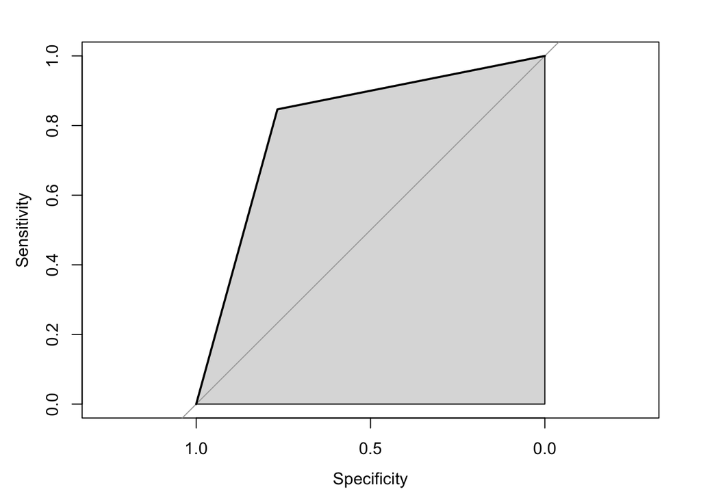

```r
#Plotting
plot(roc(test_tfidf_y$sentiment, predicted.classes), auc.polygon=TRUE)
```

```r
# Random forest tf

#TEST SET
library(randomForest)
rf <- randomForest(as.factor(sentiment) ~ ., data = train_tf_x,  proximity=TRUE)

predicted.classes = predict(rf, newdata = test_tf_x)
# Confusion Matrix
cm <- table(test_tf_y$sentiment, predicted.classes)
print("Rf for Tf model result in test set")
```

```
## [1] "Rf for Tf model result in test set"
```

```r
cm
```

```
##    predicted.classes
##       0   1
##   0 384 101
##   1  78 437
```

```r
Accuracy_3 = (cm[1,1] + cm[2,2]) / (cm[1,1] + cm[2,2] + cm[1,2] + cm[2,1])
Accuracy_3
```

```
## [1] 0.821
```

```r
auc(test_tf_y$sentiment, as.numeric(predicted.classes))
```

```
## Area under the curve: 0.8201
```

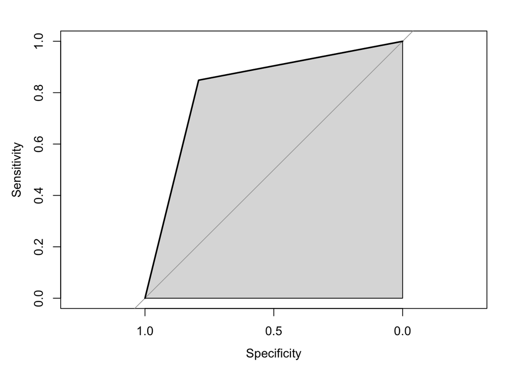

```r
#Plotting
plot(roc(test_tf_y$sentiment, as.numeric(predicted.classes)), auc.polygon=TRUE)
```

```r
# Random forest tfidf

#TEST SET
library(randomForest)
rf <- randomForest(as.factor(sentiment) ~ ., data = train_tfidf_x,  proximity=TRUE)

predicted.classes = predict(rf, newdata = test_tfidf_x)
# Confusion Matrix
cm <- table(test_tfidf_y$sentiment, predicted.classes)
print("Rf for Tf model result in test set")
```

```
## [1] "Rf for Tf model result in test set"
```

```r
cm
```

```
##    predicted.classes
##       0   1
##   0 368 117
##   1  99 416
```

```r
Accuracy_4 = (cm[1,1] + cm[2,2]) / (cm[1,1] + cm[2,2] + cm[1,2] + cm[2,1])
Accuracy_4
```

```
## [1] 0.784
```

```r
auc(test_tfidf_y$sentiment, as.numeric(predicted.classes))
```

```
## Area under the curve: 0.7833
```

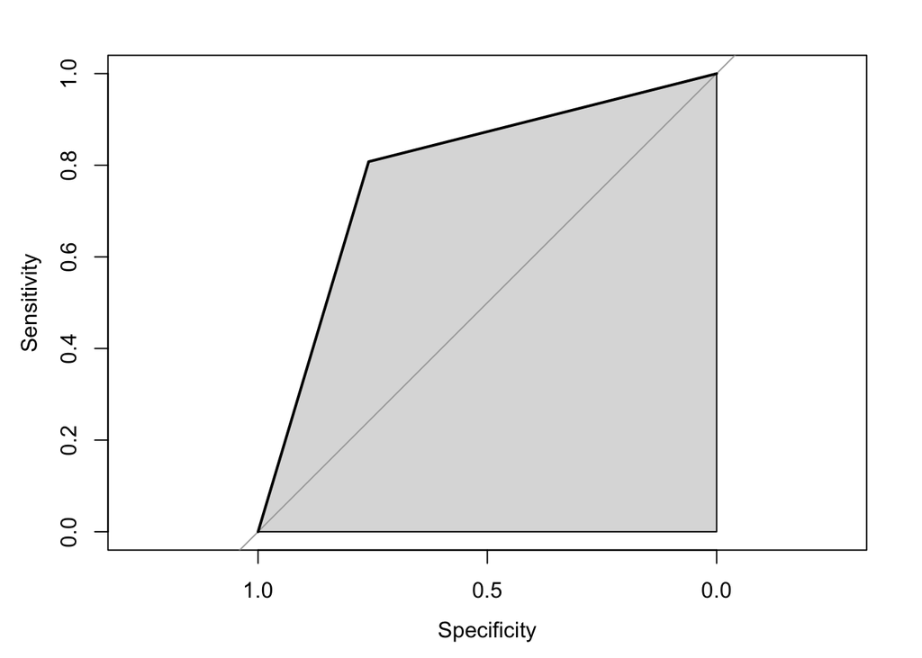

```r
#Plotting
plot(roc(test_tfidf_y$sentiment, as.numeric(predicted.classes)), auc.polygon=TRUE)
```

Step 5: Report & reflect Report the results in a table or a nice plot, briefly explain them, and make a conclusion about model performance.

```r
Model <- c("tf Logistic Regression", "tf-idf Logistic Regression", "tf Random Forest", "tf-idf Random Forest")

Accuracy <- c(Accuracy_1, Accuracy_2, Accuracy_3, Accuracy_4)

ROC <- c(0.8383, 0.8068, 0.8201, 0.7833)


class.df<- data.frame(Model, Accuracy,
                      ROC)

class.df
```

```
##                        Model Accuracy    ROC
## 1     tf Logistic Regression    0.839 0.8383
## 2 tf-idf Logistic Regression    0.808 0.8068
## 3           tf Random Forest    0.821 0.8201
## 4       tf-idf Random Forest    0.784 0.7833
```

#Explanation:

For this project a new approach was proposed since the introduction of large sparse matrixes to training algorithms requires a lot of computer resources and doesn’t live to good results.

First we preprocess our tokenized data with simple stop words removal and stemming to normalized to a compact format, then we calculate tf and tf-idf for each stem. Then we group by stem and calculate the average tf, itf and sentiment for each stem. In a way to reduce dimensionality, we normalize the average sentiment of each stem from -1 to 1 to give a negative and positive meaning to each value. Our calculated parameters are the average tf and tfidf multiplied by normalized sentiment (called score tf and score tfidf).

Now we have created our own Lexicon generated directly from the training data. It collects tf,tfidf and sentiment.

Next, we join our originals stems to our created lexicons, and we compute the average score of tf and tfidf for each id in the training data.

Finally, we prepared the test data computing its average score based in the train created Lexicon, new words are simply ignored by the join.

The data is ready to be trained and tested. We used the models: Logistic Regression and Random Forests.

From the 4 tested models, the one that performs the best in the test set is the Tf Logistic Regression model, one hypothesis of why it performs better than tf-idf is because the removal of stop words deal with the repetition of non-wanted common words such as “the”,” “in” ,etc. Furthermore, frequency is more effective for this cases in which we have short documents (reviews). In case the documents were bigger and more varied like in books, surely we will expect an outperform for tf-idf.

Having an 83% accuracy on test set is in our opinion a great result considering non-external Lexicons were used, just insights from the data and word frequencies and their relations with sentiments tagged in the reviews.

The models proposed worked well, even thought, some new reviews with words that didn’t were in the train set were introduced.